# BKA_Kriminalstatistik_2019_data_analysis

Peter von Bodelschwingh, Joshua Gawenda

12 12 2020

# German crime statistics 2019 - A data analysis

## Introduction

In this data analysis we are going to take a look at the German crime statistics from the year 2019, the special version we are looking at also shows the crime distribution about different sized cities. The data is divided for all 16 German provinces and into a general section for the whole country.  
There are also multiple files that help to determine what can be deducted from a data analysis of this set and what is out of scope.  
The data set is taken from the “Bundeskriminalamt” - the leading institution of crime detection in Germany.  
The original data set can be found here: [BKA Dataset](https://www.bka.de/DE/AktuelleInformationen/StatistikenLagebilder/PolizeilicheKriminalstatistik/PKS2019/PKSTabellen/LandFalltabellen/landFalltabellen.html)  
This data set only shows absolute numbers for all provinces in Germany, so to make the statistics comparable over all the different provinces we also included another data set, that shows the number of inhabitants for every province and the whole country.  
This data set can be found here: [German Inhabitants](https://www.destatis.de/DE/Themen/Laender-Regionen/Regionales/Gemeindeverzeichnis/Administrativ/02-bundeslaender.html)  
Later you will see that we imported on more data set. This one is generated out of a PDF from the documentation for the first data set and therefore is not available in the format we have online. It holds information about the so called sum keys of the main data set and is later used to decouple the main data set.

### Sum Keys

To understand a big part of the analysis you have to understand what sum keys are, this is what we are going to describe in this chapter.  
A key in the data set we use represents one type of crime, every crime has its own distinct key. Some crimes are just a composite of multiple other crimes, their key is then called a sum key, so every crime that is not a sum, has no children but only a parent crime.  
A key is made out of six digits, where every digit is read as a single one from left to right. In general every key that starts with the same digits is part of the same sum key, the sum key is then identified with the same starting digits followed by zeros. However this is not true in every case, some keys that end with zero have no children and therefore are no sum keys, the sum key for those keys is in most cases represented by a "*"-sign.  
One general section of crimes is therefore represented by only the first digit. There are also two whole sections of keys that are only made out of sum keys and are used by the police to study different fields of crimes.

## Import

The first step to every data analysis is to import the data into your project. The data we chose is available as an excel file so we use the package “readxl” to import the sets from excel. For the import to work properly we had to remove some unnecessary header lines in the main data set, we did that by specifying a “range” in the read_excel command.  
The “SumKeys” data set was created by us, therefore every optimization for importing where made while creating the set.  
Finally we also import the data set for the inhabitants, since this data set is not part of the main analysis, we decided to also edit it in excel to optimize it for the import and remove data that we do not need for the analysis.

```r
originalSet <- read_excel("DataSets/PKS_crime_statistics.xlsx", sheet = "Data",range = "A8:U18777")
sumKeysImport <- read_excel("DataSets/PKS_crime_statistics.xlsx", sheet = "Sumkeys")
germanInhabitants <- read_excel("DataSets/02-bundeslaender.xlsx", sheet = "inhabitants")
```

### Renaming

After the import, the names of the original data set got lost and are not descriptive anymore. To assure that the usage later on is more understandable we renamed the data set.

```r
originalSet <- originalSet %>%
                rename(
                  key = '1',
                  crime = '2',
                  province = '3',
                  detected_cases = '4',
                  detected_cases_percent = '5',
                  not_executed_cases = '6',
                  not_executed_cases_percent = '7',
                  distribution_under_20K = '8',
                  distribution_20K_to_100K = '9',
                  distribution_100K_to_500K = '10',
                  distribution_over_500K = '11',
                  distribution_unknown = '12',
                  gun_threatened = '13',
                  gun_shot = '14',
                  solved_cases = '15',
                  solved_cases_percent = '16',
                  suspects = '17',
                  male = '18',
                  female = '19',
                  non_german ='20',
                  non_german_percent = '21'
                  )
```

As a last step of importing, we can merge the inhabitants data frame into the original data frame for the analysis. This would allow to use the number of inhabitants easily in any calculation from here on.

```r
originalSet <- merge(originalSet, germanInhabitants, by = "province") %>% arrange(key)
head(originalSet)
```

|  | province | key | crime | detected_cases | detected_cases_percent | not_executed_cases | not_executed_cases_percent | distribution_under_20K | distribution_20K_to_100K | distribution_100K_to_500K | distribution_over_500K | distribution_unknown | gun_threatened | gun_shot | solved_cases | solved_cases_percent | suspects | male | female | non_german | non_german_percent | inhabitants |
| --- | --- | --- | --- | --- | --- | --- | --- | --- | --- | --- | --- | --- | --- | --- | --- | --- | --- | --- | --- | --- | --- | --- |
| 1 | Baden-Württemberg | ------ | Straftaten insgesamt | 573813 | 100 | 48562 | 8.5 | 175726 | 207084 | 132301 | 54347 | 4355 | 274 | 325 | 348664 | 60.8 | 238737 | 182574 | 56163 | 96219 | 40.3 | 11100394 |
| 2 | Bayern | ------ | Straftaten insgesamt | 603464 | 100 | 45581 | 7.6 | 235721 | 141835 | 64933 | 129814 | 31161 | 354 | 345 | 404145 | 67.0 | 289856 | 221025 | 68831 | 121928 | 42.1 | 13124737 |
| 3 | Berlin | ------ | Straftaten insgesamt | 513426 | 100 | 41505 | 8.1 | 0 | 0 | 0 | 513426 | 0 | 342 | 316 | 229532 | 44.7 | 136704 | 100677 | 36027 | 61841 | 45.2 | 3669491 |
| 4 | Brandenburg | ------ | Straftaten insgesamt | 171828 | 100 | 11278 | 6.6 | 81968 | 64415 | 24717 | 0 | 728 | 88 | 124 | 96690 | 56.3 | 65374 | 49299 | 16075 | 16303 | 24.9 | 2521893 |
| 5 | Bremen | ------ | Straftaten insgesamt | 78228 | 100 | 7288 | 9.3 | 0 | 0 | 12020 | 65869 | 339 | 67 | 43 | 38118 | 48.7 | 24101 | 18108 | 5993 | 9599 | 39.8 | 681202 |
| 6 | Bundesrepublik Deutschland | ------ | Straftaten insgesamt | 5436401 | 100 | 416594 | 7.7 | 1243451 | 1451426 | 1061629 | 1569157 | 110738 | 4512 | 4639 | 3124161 | 57.5 | 2019211 | 1514667 | 504544 | 699261 | 34.6 | 83166711 |

## Tidy

This next step includes checking for missing values and in our case splitting the data frames up, so that the provinces are decoupled from the values for whole Germany. We also need to remove all sum keys from the actual capture keys.

### Check non NA

If the data set contains empty values they are marked as NA and have to be handled somehow. However, this data set has no such values as shown in the next code chunk. Here we filter for NA values in any column and check if the row count is 0 in the end.

```r
nrow(filter_at(originalSet, 1:21, any_vars(is.na(.)))) == 0
```

```
## [1] TRUE
```

### Decouple

Like describe in the “Sum Key” section, the original data set is a mix of sum keys and capture keys. In order to not count twice in some operations we remove the sum keys from the capture keys, so the main analysis can focus on the capture keys.  
The sum keys set that we imported has two columns, one for the key and one with the value “Y” for every capture key and a “N” for every sum key. The two key sections that are only made out of sum keys are not reported in the set, so can be handled as “NA”.

```r
captureKeys <- sumKeysImport %>% filter(grepl("Y",is_sum_key))
sumKeys <- sumKeysImport %>% filter(!grepl("Y",is_sum_key))
```

To check, that the keys after the filter are all correct, we created a small algorithm that checks for sum keys based on the the rules described in the “Sum Keys” chapter. The code takes a while to run, that is why we saved the result in a vector.

```r
#filteredKeys <- c()
#for (key1 in captureKeys$key) {
#  if (!key1 %in% filteredKeys) {
#    for (key2 in captureKeys$key) {
#      if (!key2 %in% filteredKeys) {
#        if (key1 != key2) {
#          if (regexpr(paste("^", str_remove(key2, "0+$"), sep = ""), key1)[1] == 1) {
#            filteredKeys <- append(filteredKeys, key2)
#          }
#        }
#      }
#    }
#  }
#}
filteredKeys <- c("133000","141100","231200","305000","310000","315000","325000","326000","335000","340000","345000","350000","390000","435000","436000","620010","655010","670010","670020","670030")
```

After checking the resulting keys manually we found, that the keys “141100”, “231200” and “133000” were marked as capture keys, but are sum keys, so these keys have to be removed from the capture keys and added to the sum keys.

```r
captureKeys <- sumKeysImport %>% filter(grepl("Y",is_sum_key) & !(key %in% c("141100","231200","133000")))
sumKeys <- sumKeysImport %>% filter(!grepl("Y",is_sum_key) | (key %in% c("141100","231200","133000")))
```

### Filter final data frames

First to reduce duplicate data, we filtered out all crime descriptions into its own data frame, to it can be looked up afterwards.

```r
crimeCategories <-
  originalSet %>% filter(grepl("[0-9]0{5}", key)) %>%
  select(key, crime) %>%
  unique() %>%
  mutate(key = str_replace_all(key, "00000", ""))

originalSet <- originalSet %>%
  mutate(category = substring(key, 1,1)) %>%
  select(category, !category) %>%
  mutate(category = ifelse(category%in%crimeCategories$key,crimeCategories[as.integer(category)+1,2],"Other"))
crimeOverview <- originalSet %>% select(key, crime) %>% unique()
crimeOverview <- arrange(crimeOverview, key)
head(crimeOverview)
```

|  | key | crime |
| --- | --- | --- |
| 1 | ------ | Straftaten insgesamt |
| 2 | ****00 | Diebstahl insgesamt und zwar: |
| 3 | ***100 | Diebstahl insgesamt von Kraftwagen einschl. unbefugte Ingebrauchnahme |
| 4 | ***200 | Diebstahl insgesamt von Mopeds und Krafträdern einschl. unbefugte Ingebrauchnahme |
| 5 | ***300 | Diebstahl insgesamt von Fahrrädern einschl. unbefugte Ingebrauchnahme |
| 6 | ***400 | Diebstahl insgesamt von Schusswaffen |

```r
originalSet <- originalSet %>% select(!crime)
```

## Transform

In the final step before visualizing the data we need to check all the types of the values in each column an change them to a type that is usable for our analysis. We can also remove and create new Columns if necessary. In the end we are also splitting the original data frame up based on the provinces and the sum keys determined before.

### Transforming data types

In this step we first check for the different data types we have in every column. We expect to have characters as the key, a factor for the provinces and every other column should be a number.

```r
sapply(originalSet, class)
```

```
##                   category                   province
##                "character"                "character"
##                        key             detected_cases
##                "character"                  "numeric"
##     detected_cases_percent         not_executed_cases
##                  "numeric"                  "numeric"
## not_executed_cases_percent     distribution_under_20K
##                  "numeric"                  "numeric"
##   distribution_20K_to_100K  distribution_100K_to_500K
##                  "numeric"                  "numeric"
##     distribution_over_500K       distribution_unknown
##                  "numeric"                  "numeric"
##             gun_threatened                   gun_shot
##                  "numeric"                  "numeric"
##               solved_cases       solved_cases_percent
##                  "numeric"                  "numeric"
##                   suspects                       male
##                  "numeric"                  "numeric"
##                     female                 non_german
##                  "numeric"                  "numeric"
##         non_german_percent                inhabitants
##                  "numeric"                  "numeric"
```

Except for the province all values have the type expected, the next step is to transform the province into a factor.

```r
originalSet$province <- as.factor(originalSet$province)
originalSet$category <- as.factor(originalSet$category)

sapply(originalSet, class)
```

```
##                   category                   province
##                   "factor"                   "factor"
##                        key             detected_cases
##                "character"                  "numeric"
##     detected_cases_percent         not_executed_cases
##                  "numeric"                  "numeric"
## not_executed_cases_percent     distribution_under_20K
##                  "numeric"                  "numeric"
##   distribution_20K_to_100K  distribution_100K_to_500K
##                  "numeric"                  "numeric"
##     distribution_over_500K       distribution_unknown
##                  "numeric"                  "numeric"
##             gun_threatened                   gun_shot
##                  "numeric"                  "numeric"
##               solved_cases       solved_cases_percent
##                  "numeric"                  "numeric"
##                   suspects                       male
##                  "numeric"                  "numeric"
##                     female                 non_german
##                  "numeric"                  "numeric"
##         non_german_percent                inhabitants
##                  "numeric"                  "numeric"
```

```r
c1 <- levels(originalSet$category)[1]
c2 <- levels(originalSet$category)[2]
c3 <- levels(originalSet$category)[3]
c4 <- levels(originalSet$category)[4]
c5 <- levels(originalSet$category)[5]
c6 <- levels(originalSet$category)[6]
c7 <- levels(originalSet$category)[7]
c8 <- levels(originalSet$category)[8]
c9 <- levels(originalSet$category)[9]
```

### Remove calculated columns

Some columns in the data set are just calculated from the given data, so to remove the possibility of a calculation error, we remove these columns and add them on our own, once they are needed in the analysis.

```r
originalSet <- originalSet %>% select(key, category, province, inhabitants, detected_cases, solved_cases, not_executed_cases, suspects, male, female, non_german, gun_threatened, gun_shot, distribution_under_20K, distribution_20K_to_100K, distribution_100K_to_500K, distribution_over_500K, distribution_unknown)
```

### Split up data

This could also be part of the tidy step, but to reduce the amount of duplicate code for all checks, we split the data at the end. Therefore, we merge both key frames together with the original data set to separate the sum keys and the capture keys into separate data frames.

```r
originalSet %>% filter_at(vars(1:19), any_vars(is.na(.)))
```

| province | key | category | inhabitants | detected_cases | solved_cases | not_executed_cases | suspects | male | female | non_german | gun_threatened | gun_shot | distribution_under_20K | distribution_20K_to_100K | distribution_100K_to_500K | distribution_over_500K | distribution_unknown | province_id |
| --- | --- | --- | --- | --- | --- | --- | --- | --- | --- | --- | --- | --- | --- | --- | --- | --- | --- | --- |

```r
captureValues <- merge(originalSet, captureKeys) %>% select(!is_sum_key)
sumValues <- merge(originalSet, sumKeys) %>% select(!is_sum_key)
```

With the sum keys now separated, we also divide both data frames into the values for the provinces and the values for whole Germany.

```r
germanCaptureSet <-
  captureValues %>% filter(grepl("Bundesrepublik Deutschland", province))
provinceCaptureSet <-
  captureValues %>% filter(!grepl("Bundesrepublik Deutschland", province))

germanSumSet <-
  sumValues %>% filter(grepl("Bundesrepublik Deutschland", province))
provinceSumSet <-
  sumValues %>% filter(!grepl("Bundesrepublik Deutschland", province))
```

To check that the sum keys from before where separated correct we check that the sum of all detected cases in each German set is equal to the sum for the detected cases in the province set.

```r
sum(germanCaptureSet$detected_cases) == sum(provinceCaptureSet$detected_cases)
```

```
## [1] TRUE
```

```r
sum(germanSumSet$detected_cases) == sum(provinceSumSet$detected_cases)
```

```
## [1] TRUE
```

## Prepare Map

Before our analysis can start, we want to display some data on a map, with all German provinces. In this step we prepare the empty map, so that it can easily be used later on.

```r
province_json <- geojson_read("provinces.json", what = "sp")
empty_map <- tidy(province_json, area = "code") %>% mutate(province_id = id)
```

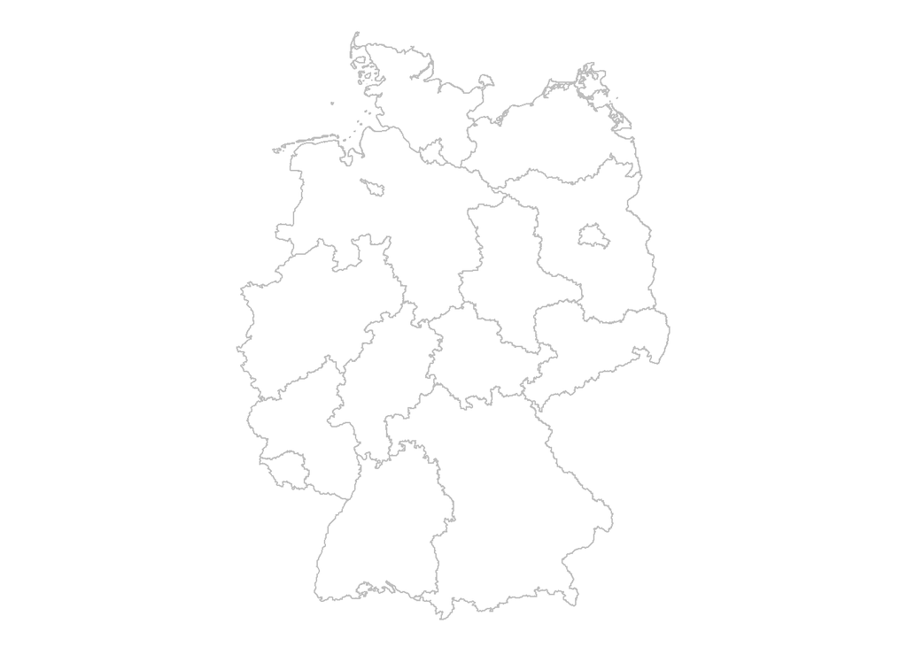

```r
ggplot(empty_map, aes(long, lat, group = group)) +
  geom_polygon(fill="white", color="grey") +
  theme_void() +
  coord_map()
```

## Analyse

Once the data is imported, tidied and transformed the analysis can start. To first get a general impression over the data that we have, we used the standard plot command, that creates a simple chart for every column. The data frame that we use for all of the next instructions is the one with only the values for whole Germany. We first want to find correlations in there.  
To make the first general data analysis more readable, we need to remove the outliers in the data. All the data in this data set is bound to the number of detected cases, so if the number of detected cases is 0 all other columns will also be 0 and the other way around, if there is a high number of detected cases, the possibility of high numbers in the other columns is pretty high (Those cases will be analyzed later on).  
To find the number of detected cases where there are the most cases, we find the mean of detected cases. To do that we use the summary function of R.

```r
summary(germanCaptureSet$detected_cases)
```

```
##     Min.  1st Qu.   Median     Mean  3rd Qu.     Max.
##      0.0     21.2    181.5   7172.0   1688.2 386517.0
```

Now we just filter out all rows where the number of detected cases is larger than 7172. For now we are also not interested in the rows where there are no cases, so we also filter out those.

```r
cutSet <- filter(germanCaptureSet, detected_cases > 0 & detected_cases <= 7172)
summary(cutSet$detected_cases)
```

```
##    Min. 1st Qu.  Median    Mean 3rd Qu.    Max.
##     1.0    25.0   136.5   778.3   775.2  7000.0
```

To now get a general view on how the data is structured across the data frame we use the plot command, that creates simple plots for every column in the frame.

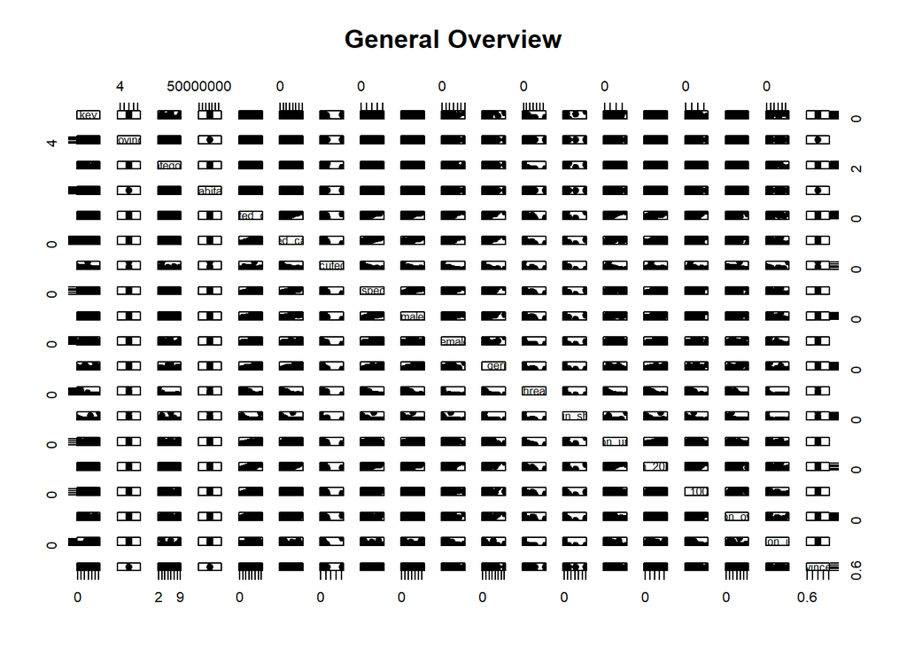

```r
plot(cutSet, main = "General Overview", col = "#000000", pch = 19)
```

Based on these plots we found a few interesting correlations of data that we now are going to discuss in detail.

### Detected Cases vs Solved Cases

The first thing that we noticed was, that there seems to be a relation between the number of detected cases and the number of solved cases. Next we enlarge this plot and filter out all rows where the number of solved cases is larger than the number of detected cases, because those would be part of a measurement error. We again also remove those cases where the number of detected cases is 0.

```r
filtered <- filter(germanCaptureSet, detected_cases >= solved_cases & detected_cases > 0)
```

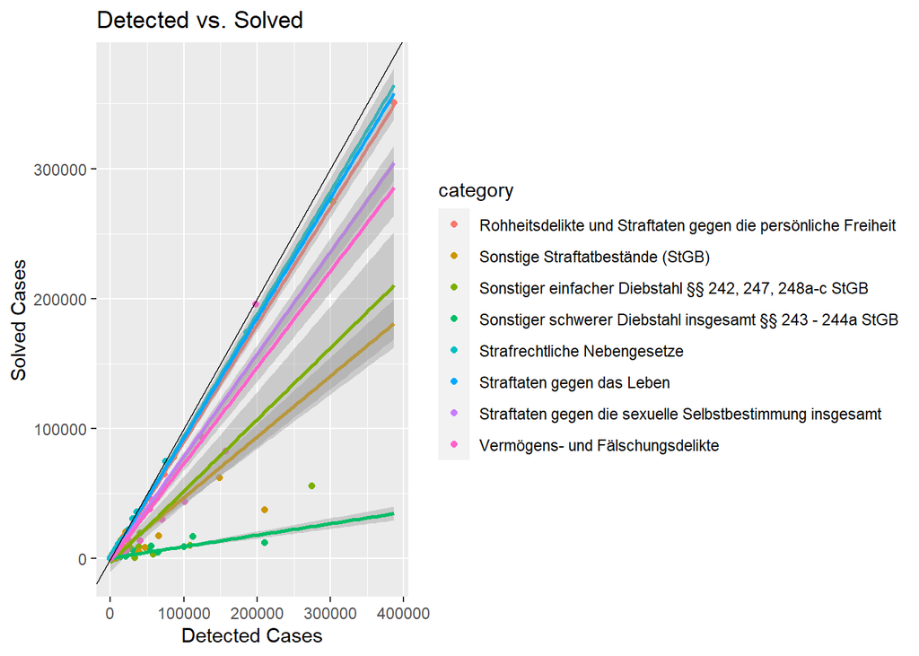

```r
ggplot(filtered, aes(detected_cases, solved_cases, color = category)) +
  geom_point(show.legend = T) +
  geom_smooth(method = "lm", fullrange = T, show.legend = F) +
  geom_abline(coef = c(0, 1)) +
  labs(title = "Detected vs. Solved", y = "Solved Cases", x ="Detected Cases")
```

This plot shows the relation between detected and solved cases for each major crime category. The black line displayed in this plot shows the optimal line, where the number of detected cases is equal to the number of solved cases, so those crimes where every case was solved. The closer a dot or a colored line is to this line, the higher is the solvage rate for the specific crime.  
Lets now take a closer look at the different solvage rates.

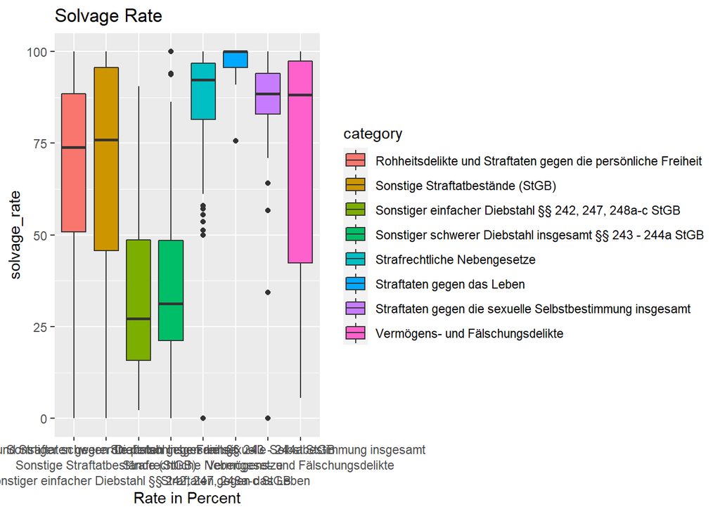

```r
filtered <- filtered %>% mutate(solvage_rate = solved_cases/detected_cases*100)
ggplot(filtered, aes(category, solvage_rate, fill = category)) +
  geom_boxplot() +
  scale_x_discrete(guide = guide_axis(n.dodge=3)) +
  labs(title = "Solvage Rate", x = "Rate in Percent")
```

Lets also get the number to these graphs.

```r
descr(filter(filtered, category == c2)$solvage_rate)
```

|  | var | type | label | n | NA.prc | mean | sd | se | md | trimmed | range | iqr | skew |
| --- | --- | --- | --- | --- | --- | --- | --- | --- | --- | --- | --- | --- | --- |
| 1 | dd | numeric | dd | 79 | 0 | 66.80086 | 26.5866 | 2.991226 | 73.89969 | 70.10006 | 100 (0-100) | 37.56903 | -1.043939 |

```r
c2
```

```
## [1] "Rohheitsdelikte und Straftaten gegen die persönliche Freiheit"
```

```r
descr(filter(filtered, category == c3)$solvage_rate)
```

|  | var | type | label | n | NA.prc | mean | sd | se | md | trimmed | range | iqr | skew |
| --- | --- | --- | --- | --- | --- | --- | --- | --- | --- | --- | --- | --- | --- |
| 1 | dd | numeric | dd | 183 | 0 | 68.70957 | 29.10952 | 2.151838 | 76 | 71.54757 | 100 (0-100) | 49.88228 | -0.6287047 |

```r
c3
```

```
## [1] "Sonstige Straftatbestände (StGB)"
```

```r
descr(filter(filtered, category == c4)$solvage_rate)
```

|  | var | type | label | n | NA.prc | mean | sd | se | md | trimmed | range | iqr | skew |
| --- | --- | --- | --- | --- | --- | --- | --- | --- | --- | --- | --- | --- | --- |
| 1 | dd | numeric | dd | 49 | 0 | 34.80276 | 23.89454 | 3.413505 | 27.19893 | 32.88646 | 88.2 (2.29-90.49) | 32.7893 | 0.6898627 |

```r
c4
```

```
## [1] "Sonstiger einfacher Diebstahl §§ 242, 247, 248a-c StGB"
```

```r
descr(filter(filtered, category == c5)$solvage_rate)
```

|  | var | type | label | n | NA.prc | mean | sd | se | md | trimmed | range | iqr | skew |
| --- | --- | --- | --- | --- | --- | --- | --- | --- | --- | --- | --- | --- | --- |
| 1 | dd | numeric | dd | 86 | 0 | 38.0718 | 23.9725 | 2.585021 | 31.30055 | 35.90544 | 100 (0-100) | 27.29789 | 0.8605299 |

```r
c5
```

```
## [1] "Sonstiger schwerer Diebstahl insgesamt §§ 243 - 244a StGB"
```

```r
descr(filter(filtered, category == c6)$solvage_rate)
```

|  | var | type | label | n | NA.prc | mean | sd | se | md | trimmed | range | iqr | skew |
| --- | --- | --- | --- | --- | --- | --- | --- | --- | --- | --- | --- | --- | --- |
| 1 | dd | numeric | dd | 173 | 0 | 86.96561 | 14.52304 | 1.104166 | 92.26519 | 89.35926 | 100 (0-100) | 15.39881 | -2.059383 |

```r
c6
```

```
## [1] "Strafrechtliche Nebengesetze"
```

```r
descr(filter(filtered, category == c7)$solvage_rate)
```

|  | var | type | label | n | NA.prc | mean | sd | se | md | trimmed | range | iqr | skew |
| --- | --- | --- | --- | --- | --- | --- | --- | --- | --- | --- | --- | --- | --- |
| 1 | dd | numeric | dd | 12 | 0 | 96.24533 | 7.08082 | 2.044057 | 100 | 97.92641 | 24.32 (75.68-100) | 4.345672 | -2.602946 |

```r
c7
```

```
## [1] "Straftaten gegen das Leben"
```

```r
descr(filter(filtered, category == c8)$solvage_rate)
```

|  | var | type | label | n | NA.prc | mean | sd | se | md | trimmed | range | iqr | skew |
| --- | --- | --- | --- | --- | --- | --- | --- | --- | --- | --- | --- | --- | --- |
| 1 | dd | numeric | dd | 50 | 0 | 84.94984 | 17.03388 | 2.408954 | 88.48586 | 88.12763 | 100 (0-100) | 11.11149 | -3.227229 |

```r
c8
```

```
## [1] "Straftaten gegen die sexuelle Selbstbestimmung insgesamt"
```

```r
descr(filter(filtered, category == c9)$solvage_rate)
```

|  | var | type | label | n | NA.prc | mean | sd | se | md | trimmed | range | iqr | skew |
| --- | --- | --- | --- | --- | --- | --- | --- | --- | --- | --- | --- | --- | --- |
| 1 | dd | numeric | dd | 75 | 0 | 72.11295 | 29.54377 | 3.411421 | 88.23529 | 75.30833 | 94.35 (5.65-100) | 54.87961 | -0.7795344 |

```r
c9
```

```
## [1] "Vermögens- und Fälschungsdelikte"
```

```r
descr(filter(filtered, category == c4 | category == c5)$solvage_rate)
```

|  | var | type | label | n | NA.prc | mean | sd | se | md | trimmed | range | iqr | skew |
| --- | --- | --- | --- | --- | --- | --- | --- | --- | --- | --- | --- | --- | --- |
| 1 | dd | numeric | dd | 135 | 0 | 36.88526 | 23.907 | 2.057587 | 30.78292 | 34.6827 | 100 (0-100) | 29.67836 | 0.7871699 |

```r
"Crimes associated with theft"
```

```
## [1] "Crimes associated with theft"
```

```r
descr(filtered$solvage_rate)
```

|  | var | type | label | n | NA.prc | mean | sd | se | md | trimmed | range | iqr | skew |
| --- | --- | --- | --- | --- | --- | --- | --- | --- | --- | --- | --- | --- | --- |
| 1 | dd | numeric | dd | 707 | 0 | 68.86363 | 29.61959 | 1.113959 | 80 | 72.11956 | 100 (0-100) | 48.58267 | -0.7381131 |

```r
"General"
```

```
## [1] "General"
```

```r
province_filtered <- provinceCaptureSet %>%
  filter(detected_cases >= solved_cases & detected_cases > 0) %>%
  mutate(solvage_rate = solved_cases / detected_cases * 100) %>%
  select(province_id, solvage_rate)

province_filtered <- aggregate(province_filtered, list(province_filtered$province_id),FUN=mean) %>%
  select(!province_id) %>%
  rename(province_id = "Group.1")
```

[output not shown]

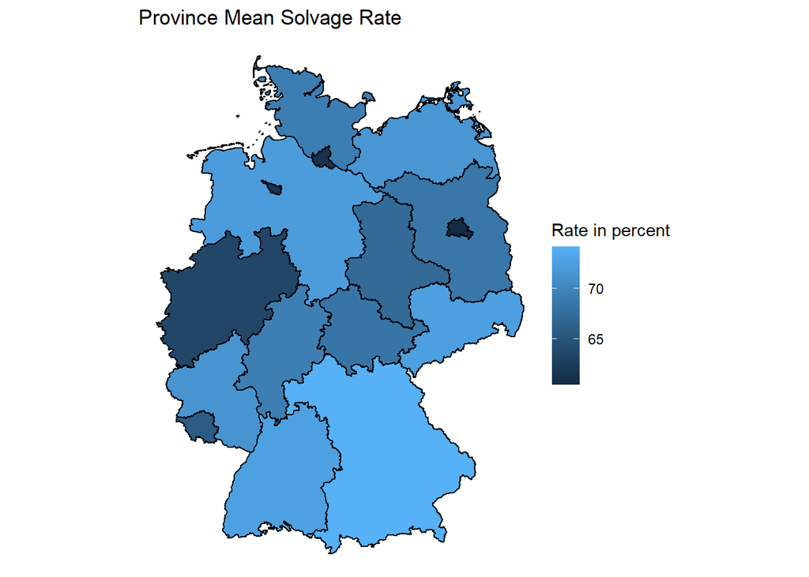

```r
map_data = empty_map %>% left_join(., province_filtered, by = "province_id")

ggplot(map_data, aes(long, lat, group = group, fill = solvage_rate)) +
  geom_polygon(color = "black") +
  geom_polygon(data = filter(map_data, province_id == 3), color = "black") +
  geom_polygon(data = filter(map_data, province_id == 5), color = "black") +
  theme_void() +
  coord_map() +
  labs(title = "Province Mean Solvage Rate", fill = "Rate in percent")
```

When looking on this map, it is clearly visible, that there are five relatively dark provinces on the map, which means, that they have the lowest solvage rate in Germany. The four out of these provinces are the smallest provinces in Germany while the fifth has no connection in size to the others.  
To now get a better picture on which provinces are the most dangerous, based on their mean solvage rate and their crimes per inhabitant, we create a second map that shows the crimes per 10.000 inhabitants.

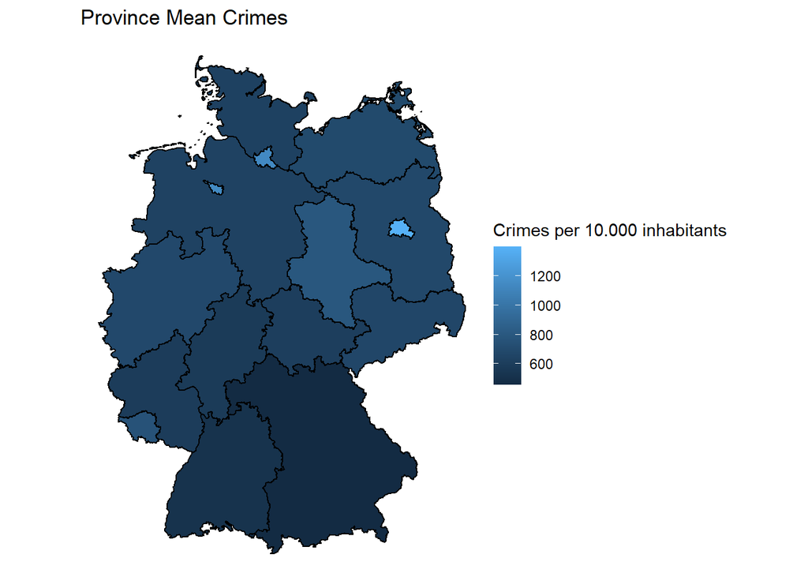

```r
province_filtered <- provinceCaptureSet %>%
  filter(detected_cases >= solved_cases & detected_cases > 0) %>%
  mutate(crime_rate = detected_cases / inhabitants * 10000) %>%
  select(province_id, crime_rate) %>%
  mutate(province_id = as.integer(province_id))

province_filtered <- aggregate(province_filtered, list(province_filtered$province_id),FUN=sum) %>%
  select(!province_id) %>%
  rename(province_id = "Group.1") %>%
  mutate(province_id = as.character(province_id))

map_data = empty_map %>% left_join(., province_filtered, by = "province_id")

ggplot(map_data, aes(long, lat, group = group, fill = crime_rate)) +
  geom_polygon(color = "black") +
  geom_polygon(data = filter(map_data, province_id == 3), color = "black") +
  geom_polygon(data = filter(map_data, province_id == 5), color = "black") +
  theme_void() +
  coord_map() +
  labs(title = "Province Mean Crimes", fill = "Crimes per 10.000 inhabitants")
```

And again, the three lightest spots on the map, therefore the ones with the highest crime rate, are the three smallest provinces in Germany. Also the other two provinces from the last map have a relatively light tint, a bit above the average, which could indicate a possible relationship between the crime rate and the solvage rate.  
It is also interesting to see, that the eastern provinces have a slightly higher crime rate than the rest of Germany, which could have a possible explanation in the fact, that Germany was separated by a wall for many years. After the wall was destroyed, the western provinces implemented a new tax to support the eastern provinces, because they needed financial help after those years. So a because the eastern provinces are in general more poor, it is possible, that there is a higher crime rate because of it.

### Solved Cases vs Suspects

Now that we analyzed the aspects of the solvage rate in Germany, we want to have a look at the suspects involved in solving a case. How many suspects do you need to close a case? Are more suspects better for solving the case?  
One note upfront for this, if a group of people is committing a crime together, every one of them will get their own law suite, which means that every crime listed in our data set has only one person that executed it. Also a person will only be listed once per crime, so if person x committed fraud twice and theft once, then he will appear both in the fraud and theft section only once as a suspect. This means, that a crime with 100% solvage rate and a lower amount of suspects than detected cases is only explainable by repead offenders.  
For sum keys about the suspects the same rules apply, so a suspect that commits multiple crimes for the same sum key will only be counted once, so summing up all capture keys contained in a sum key will often lead to a higher number of suspects than what is written in the sum key.

Since we calculated the solvage rate in the last chapter for a filtered dataframe, we are now adding the solvage rate to the germanCaptureSet, to have these values stored, including those values with a solvage rate greater than 100 % to avoid data loss.

```r
germanCaptureSet <- germanCaptureSet %>% mutate(solvage_rate = solved_cases/detected_cases)
```

Referring back to our overview again, we also noticed that there seems to be a correlation between solved cases and suspects:

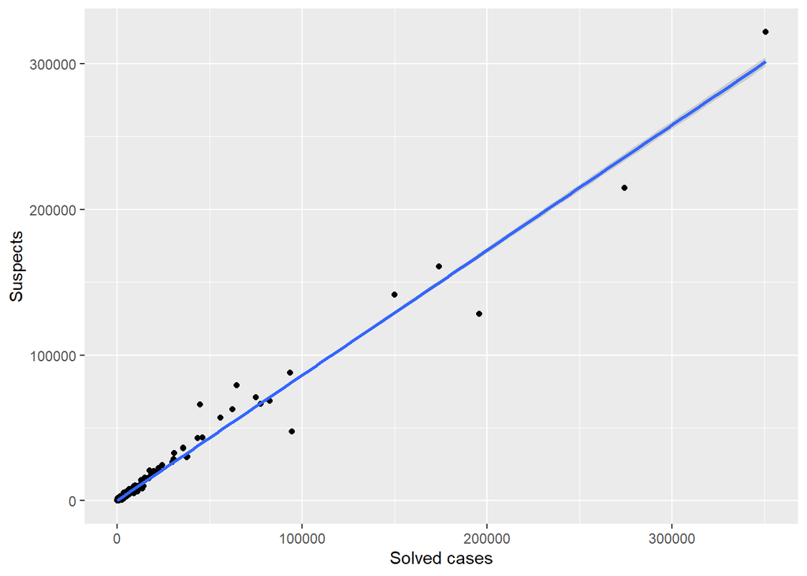

```r
ggplot(data = germanCaptureSet, mapping = aes(x = solved_cases,y = suspects)) +
  geom_point() +
  geom_smooth(method ="lm") +
  labs(x = "Solved cases", y = "Suspects")
```

Since we want to calculate the suspects rate later on we have to remove all rows where no crimes have been detected and those rows where no suspects could be found because a division would lead to NA values.

```r
solvedCasesFiltered <- filter(germanCaptureSet, detected_cases >0, suspects >0)
```

Lets take a detailed look into the filtered plot now, by differenciating between the categories, because we would like to know why there are a few values deviating:

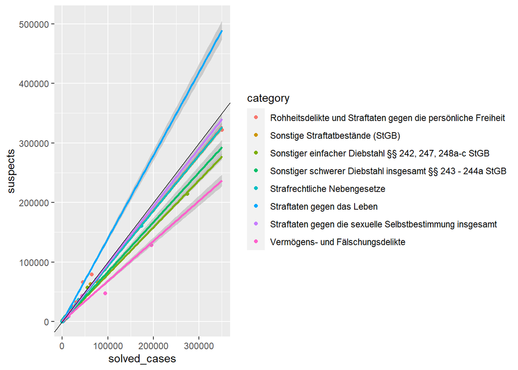

```r
ggplot(solvedCasesFiltered, aes(solved_cases, suspects, color = category)) +
  geom_point(show.legend = T) +
  geom_smooth(method = "lm", fullrange = T, show.legend = F) +
  geom_abline()
```

```r
  labs(title = "Suspects vs. Solved", y = "Solved Cases", x ="Suspects")
```

```
## $y
## [1] "Solved Cases"
##
## $x
## [1] "Suspects"
##
## $title
## [1] "Suspects vs. Solved"
##
## attr(,"class")
## [1] "labels"
```

As can be seen in the plot above, only the blue line which determines crimes against life really deviates in its curve from the others.  
Crimes against life has a higher suspects rate. Lets calculate the suspects rate per category with the mean:

```r
# mean solved cases by category
sum_solved<- aggregate(x = germanCaptureSet$solved_cases,                # Specify data column
          by = list(germanCaptureSet$category),              # Specify group indicator
          FUN = mean) %>% rename("sum_solved" = x)
# mean amount of suspects by category
sum_suspects<- aggregate(x = germanCaptureSet$suspects,                # Specify data column
          by = list(germanCaptureSet$category),              # Specify group indicator
          FUN = mean) %>% rename("sum_suspects" = x)
# merge and divide
(percentage_solved <- merge(sum_solved,sum_suspects, by = "Group.1") %>% rename("category" = "Group.1")  %>% mutate("suspects per case" = sum_suspects/sum_solved))
```

| category | sum_solved | sum_suspects | suspects per case |
| --- | --- | --- | --- |
| Rohheitsdelikte und Straftaten gegen die persönliche Freiheit | 6578.4466 | 6699.680 | 1.0184288 |
| Sonstige Straftatbestände (StGB) | 3050.2539 | 2956.373 | 0.9692220 |
| Sonstiger einfacher Diebstahl §§ 242, 247, 248a-c StGB | 8442.4286 | 7258.633 | 0.8597802 |
| Sonstiger schwerer Diebstahl insgesamt §§ 243 - 244a StGB | 1339.3295 | 1183.614 | 0.8837359 |
| Strafrechtliche Nebengesetze | 3153.0765 | 3033.148 | 0.9619645 |
| Straftaten gegen das Leben | 211.6154 | 296.000 | 1.3987641 |
| Straftaten gegen die sexuelle Selbstbestimmung insgesamt | 1108.0000 | 1076.904 | 0.9719349 |
| Vermögens- und Fälschungsdelikte | 8947.5584 | 6710.727 | 0.7500065 |

Now it is very interesting to see that the category with the highest suspects per case rate is also the one with the highest solvage rate. Because these calculations are only grouped by the category, we are looking into the whole dataframe now by using a boxplot:

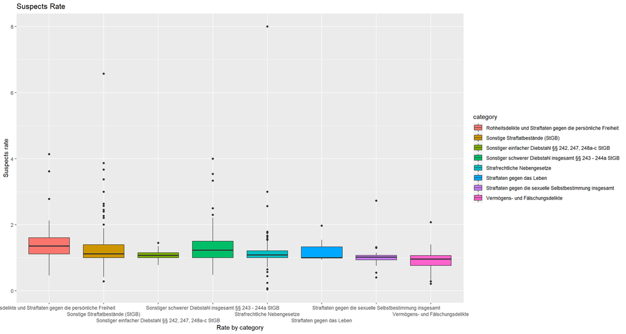

```r
solvedCasesFiltered <- solvedCasesFiltered %>% mutate(suspects_rate = suspects/solved_cases)
ggplot(solvedCasesFiltered, aes(category, suspects_rate, fill = category)) +
  geom_boxplot() +
  scale_x_discrete(guide = guide_axis(n.dodge=3)) +
  labs(title = "Suspects Rate", x = "Rate by category", y = "Suspects rate")
```

As already been explained in the chapter introduction there can be repead offenders. This is the case when we have a solvage rate of 100% for a crime and a suspects rate below 1,0.  
The points of the boxplot that are below 1 are represented by this table:

```r
temp <- solvedCasesFiltered %>% filter( solvage_rate ==1, suspects_rate < 1)
temp <- merge(temp,crimeOverview, by = "key")
temp %>% select(key, category, crime, suspects_rate)
```

| key | category | crime | suspects_rate |
| --- | --- | --- | --- |
| 020030 | Straftaten gegen das Leben | Tötung auf Verlangen § 216 StGB | 0.94117647 |
| 143520 | Straftaten gegen die sexuelle Selbstbestimmung insgesamt | Verbreitung und Herstellung von Jugendpornographie gewerbs-/bandenmäßig § 184c Abs. 2 StGB | 0.75000000 |
| 550010 | Vermögens- und Fälschungsdelikte | Gewerbs- und bandenmäßiges Geldfälschung § 146 Abs. 2 StGB | 0.36158192 |
| 552010 | Vermögens- und Fälschungsdelikte | Inverkehrbringen von Falschgeld § 146 Abs. 1 Nr. 3 StGB | 0.83257662 |
| 657300 | Sonstige Straftatbestände (StGB) | Bestechlichkeit und Bestechung, Vorteil großen Ausmaßes § 300 Satz 2 Nr. 1 StGB | 0.28225806 |
| 670030 | Sonstige Straftatbestände (StGB) | Vollrausch | 0.90384615 |
| 725520 | Strafrechtliche Nebengesetze | Straftaten gegen § 85 Asylgesetz | 0.71368715 |
| 727100 | Strafrechtliche Nebengesetze | Illegale Ausfuhr von Kulturgut § 83 Abs. 1 Nr. 1, 2 und Abs. 2 KGSG | 0.07692308 |
| 742010 | Strafrechtliche Nebengesetze | Infektionsschutzgesetz | 0.44262295 |

#### Outliers analysis

In all of these rows we have a certain amount of repead offenders. Unforunately there is no pattern, thats why we will check the outliers above the IQR now.  
Lets do this by looking at the “Sonstige Straftatbestände” category.

```r
temp <- solvedCasesFiltered %>% filter(category == c3, suspects_rate >= 2)
temp <- merge(temp,crimeOverview, by = "key")
(temp <- temp %>% select(crime,suspects_rate ) %>% arrange(desc(suspects_rate)))
```

| crime | suspects_rate |
| --- | --- |
| Bildung krimineller Vereinigungen | 6.571429 |
| Besonders schwerer Landfriedensbruch § 125a StGB | 3.869249 |
| Gefangenenmeuterei | 3.666667 |
| Landfriedensbruch § 125 StGB | 3.374269 |
| Vollstreckung gegen Unschuldige | 3.000000 |
| Luftverunreinigung - besonders schwerer Fall | 3.000000 |
| Unerlaubter Umgang mit anderen gefährlichen Stoffen und Gütern § 328 Abs. 3 StGB - besonders schwerer Fall | 3.000000 |
| Sonstige Bandenhehlerei § 260 Abs. 1 Nr. 2 StGB | 2.636364 |
| Unerlaubtes Betreiben von Anlagen § 327 Abs. 2 - besonders schwerer Fall | 2.571429 |
| Schwerer Hausfriedensbruch § 124 StGB | 2.448276 |

[output cut: 7 more lines]

Researching the upper four crimes showed that these crimes can only be commited by more than one suspects. This explains the high outliers. Lets see whether this applies to the upper outliers of the “Strafrechtliche Nebengesetze” category as well. Unfortunately its not as easy as for the last category to determine the upper outliers, thats why we are calculating this now, by filtering out all values above Inter quartile 3*1,5, that determines the start of the upper outliers:

```r
# filter category == "Strafrechtliche Nebengesetze"
upper_outlier_start <- solvedCasesFiltered %>% filter(category == c6)
# determine 3rd quartile ending at 75%
upper_outlier_start <-quantile(upper_outlier_start$suspects_rate, .75)
# retrieve IQR using IQR()
IQR <- IQR(solvedCasesFiltered$suspects_rate[solvedCasesFiltered$category == c6])
# multiply IQR*1,5 and add to 3rd quantile to get outliers start
(upper_outlier_start <- upper_outlier_start+1.5*IQR)
```

```
##      75%
## 1.535714
```

```r
temp <- solvedCasesFiltered %>% filter(category == c6, suspects_rate > upper_outlier_start)
temp <- merge(temp,crimeOverview, by = "key")
(temp <- temp %>% select(crime,suspects_rate,detected_cases, solved_cases ) %>% arrange(desc(suspects_rate)))
```

| crime | suspects_rate | detected_cases | solved_cases |
| --- | --- | --- | --- |
| Straftaten gemäß § 2 des Gesetzes zur Bekämpfung internationaler Bestechung (IntBestG) | 8.000000 | 1 | 1 |
| Einschleusen mit Todesfolge § 97 Abs. 1 Aufenthaltsgesetz | 8.000000 | 1 | 1 |
| Genossenschaftsgesetz | 3.000000 | 1 | 1 |
| Arbeitnehmerüberlassungsgesetz | 3.000000 | 2 | 2 |
| Verstöße gemäß § 30 Abs. 1 Nr. 1 BtMG | 2.561404 | 119 | 114 |
| Schmuggel von Heroin | 1.788235 | 124 | 85 |
| Aktiengesetz | 1.750000 | 5 | 4 |
| Gewerbs- und bandenmäßige Verleitung zur missbräuchlichen Asylantragstellung § 84a Asylgesetz | 1.666667 | 4 | 3 |
| Sonstige Straftaten im Zusammenhang mit Lebensmitteln - soweit nicht unter anderen Schlüsseln zu erfassen - | 1.625000 | 29 | 24 |
| Erschleichen oder Gebrauch eines Aufenthaltstitels (Visum) durch Scheinehe | 1.571429 | 211 | 210 |

[output cut: 3 more lines]

Looking at the two highest outliers, we could assume that the suspects are the same suspects for both crimes.  
If we dive deeper into the dataframe we can look at male, female and non german:

```r
(temp <- solvedCasesFiltered %>% filter(suspects_rate == 8) %>% select(suspects_rate,detected_cases, solved_cases, male, female, non_german ) %>% arrange(desc(suspects_rate)))
```

| suspects_rate | detected_cases | solved_cases | male | female | non_german |
| --- | --- | --- | --- | --- | --- |
| 8 | 1 | 1 | 7 | 1 | 2 |
| 8 | 1 | 1 | 7 | 1 | 8 |

These details confirm that the suspects are not the same suspects for the crimes. Therefore the outlier is also a value we should keep in our frame when we want to move on with the analysis.  
#### Linear model: Since we checked the highest outliers now we can try to generate a linear model, in order to check how the amount of suspects influences the amount of solved cases, by first refilter the germanCaptureSet, to rows with cases only:

```r
germanCasesSet <- germanCaptureSet %>% filter(detected_cases> 0)
```

The reason we are not taking the solvedCasesFiltered set is because we removed values without suspects.  
Modelling this data would lead to deviating, not accurate results. Now, we first check the correlation of suspects and solved cases in the germanCasesSet:

```r
cor(germanCasesSet$solved_cases, germanCasesSet$suspects)
```

```
## [1] 0.9887327
```

The correlation leads to the question: Is the amount of solved cases affected by the amount of suspects? First step: Generate linear model using lm():

```r
reg <- lm(solved_cases~suspects, data =germanCasesSet)
summary(reg)
```

```
##
## Call:
## lm(formula = solved_cases ~ suspects, data = germanCasesSet)
##
## Residuals:
##    Min     1Q Median     3Q    Max
## -30115      6    143    168  49915
##
## Coefficients:
##                Estimate  Std. Error t value            Pr(>|t|)
## (Intercept) -170.711755  127.066273  -1.343                0.18
## suspects       1.137880    0.006474 175.751 <0.0000000000000002 ***
## ---
## Signif. codes:  0 '***' 0.001 '**' 0.01 '*' 0.05 '.' 0.1 ' ' 1
##
## Residual standard error: 3314 on 708 degrees of freedom
## Multiple R-squared:  0.9776, Adjusted R-squared:  0.9776
## F-statistic: 3.089e+04 on 1 and 708 DF,  p-value: < 0.00000000000000022
```

In the next step, we will look at the residuals to see the spread:  
Proof of residuals:  
Residuals are the difference of the observed y values (solved cases) predicted values of y from our dataframe. If the prediction is higher than the observed value, the residual is negative. If predicted and observed value are equal the residual is zero. Therefore if we sum up the collected residuals we know whether our formula is accurate or not:

```r
sum(reg$residuals)
```

```
## [1] 0.00000000001143441
```

The result is almost 0, which is a good sign for the spread of residuals.  
Still the frequency of residuals up and below zero has to be analyzed:

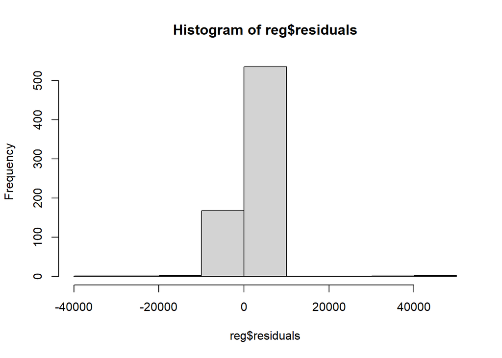

```r
hist(reg$residuals)
```

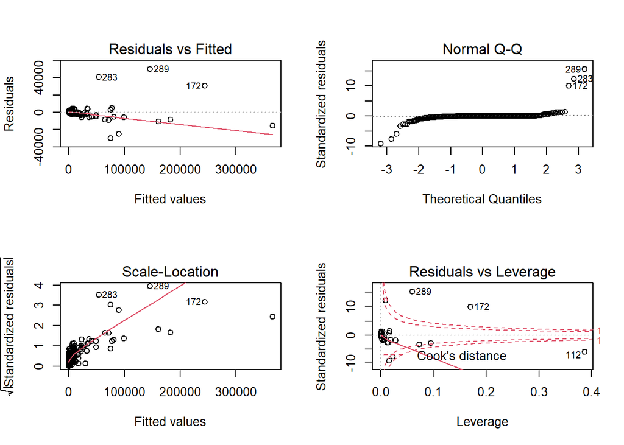

```r
par(mfrow=c(2,2))
plot(reg)
```

```r
par(mfrow=c(1,1))
```

##### Residuals vs Fitted

As we can see, the red line seems to not follow the dotted line because of the non equal spread of positive and negative residuals. Also there are a few observations that highly influence the model, in the following rows of the germanCasesSet: 283,289 and 172.

##### Normal Q Q

We can see skewed residuals in the upper and lower quantiles. This tells us what we already thought. The spread inside the population is not equal, especially in the start and the end. This is confirmed when you take a look back at the intercept values of the reg summary. It also explains the high SSE at the intercept.Nevertheless, the curve looks good, it follows the dotted line.

##### Residuals vs Leverage

There are a few influential cases here, but only two of them areabove the dotted line: 289 and 172. Since there are a lot of values at the start of the dotted line, we have to be careful interpreting predicted values because: We have four values beneath the red lines which have a high influence.

##### Scale location

This plot also shows the non equal spread of residuals. As we can see, the red line goes up, this shows that thea ssumption of homoscedasticity is not given. The residuals seem also not to be randomly scattered.

#### Conclusion Solved Cases vs Suspects

Since we have proven a high accuracy of the model with the R squared, we could take the model, but when it comes to the intercept the model is not accurate. This makes sense because we are of course not interested in negative solved cases. Also, the results must be treated with caution, since there can be crimes which require multiple suspects by law and the unequal spread of residuals. However we can try to check the accurary to finish this chapter:Lets get the max value of lets say the third quartile:

```r
q3 <- quantile(germanCasesSet$solved_cases,.75)
val <- filter(germanCasesSet, solved_cases <= q3)
max <- max(val$solved_cases)
# get number of solved cases and suspects:
(actual <-germanCasesSet %>% select(solved_cases,suspects) %>% filter(solved_cases == max))
```

| solved_cases | suspects |
| --- | --- |
| 1267 | 1675 |

These are the values of our set.  
Now lets compare the number of suspects calculated by the model using Y (solved cases) = mx + b:  
1.267 = 1.137880 * x -170,711755 | +170,711755  
1.437,711755 = 1,137880 * x | /1,137880  
1.263,500329 = x (amount of suspects)

This is the predicted amount of suspects. The actual amount of suspects is 1675.  
But we can also try to predict the solved cases when we know x. (The amount of suspects) to compare the calculated value with the actual of 1267 cases by 1675 suspects.:  
Y = 1.137880*1675 - 170,711755  
Y = 1735,237245

The model predicts an amount of ~ 1735,23 solved cases when we have 1675 suspects.  
The same result is displayed by applying predict():

```r
p <- as.data.frame(1675)
colnames(p) <- "suspects"

(predicted <- predict(reg, newdata = p))
```

```
##        1
## 1735.237
```

The deviation of actual and predicted value is calculated here:

```r
# in percentage

(1 - (max/predicted))*100
```

```
##        1
## 26.98403
```

The deviation about 26 percent. This is a high deviation and it confirmed what we expected earlier: Solved cases are also influenced by other factors, but the amount of suspects definetely has a high influence. In conclusion: The model predictions for a less amount of solved cases are not accurate, as well as when it comes to solved cases at the end because of outliers. The high deviation in the example we are using here is also explained because of the intercept we had to use in the formula. Since the intercept itseld has a high SSE and a high P value, it explains the deviation mentioned above. To check the influence of outliers in the dataframe we can filter by the category with the less amount of outliers which was “Straftaten gegen das Leben” (Crimes against life.)

```r
germanCasesLifeCrimes <- filter(germanCasesSet, category == c7)
regFiltered <- lm(solved_cases~suspects, data =germanCasesLifeCrimes)
summary(regFiltered)
```

```
##
## Call:
## lm(formula = solved_cases ~ suspects, data = germanCasesLifeCrimes)
##
## Residuals:
##     Min      1Q  Median      3Q     Max
## -52.088   0.103   0.246   4.326  39.195
##
## Coefficients:
##             Estimate Std. Error t value           Pr(>|t|)
## (Intercept)  0.18226    7.15017   0.025               0.98
## suspects     0.71435    0.01042  68.557 0.0000000000000106 ***
## ---
## Signif. codes:  0 '***' 0.001 '**' 0.01 '*' 0.05 '.' 0.1 ' ' 1
##
## Residual standard error: 21.9 on 10 degrees of freedom
## Multiple R-squared:  0.9979, Adjusted R-squared:  0.9977
## F-statistic:  4700 on 1 and 10 DF,  p-value: 0.00000000000001063
```

The first impression is that the increase of suspects is way lower than it was in the overall model. We could now start to analyse this, but since the degree of freedom is only 10 (caused by filtering the categories), we do not need to move on because the number of samples is simply too low. This also explains why there is only one outlier in the boxplot for this category: 10 DF + 2 variables used in the model = 12 rows only.